# The therapeutic potential of exercise in post-traumatic stress disorder and its underlying mechanisms. Update 1.

Simonne Wright, Virginia Chiocchia

2025-05-17

# Results

## Study description

12 of the studies were RCTs, and 1 was a crossover RCT (Greene & Petruzzello, 2022).The specific intervention and comparison groups for the 13 eligible studies are presented in Table 1.

| Study | Intervention | Comparison | Exercise type | Therapy | TAU | Attention control |
| --- | --- | --- | --- | --- | --- | --- |
| Bryant2023 | exercise + therapy | attention control + therapy | aerobic | exposure therapy | NA | static stretching |
| Crombie2021 | exercise + extinction learning | attention control + extinction learning | aerobic | extinction learning | NA | NA |
| Greene2022a | exercise only | attention control | mixed | NA | NA | remained sedentary in the lab |
| Greene2022b | exercise only | attention control | aerobic | NA | NA | remained sedentary in the lab |
| Huseth2022 | exercise only | WLC | aerobic | NA | NA | NA |
| McGranahan2025 | exercise only | WLC | aerobic | NA | NA | NA |
| Nordbrandt2020 | exercise + TAU | TAU | mixed | NA | combination: medical doctor, 1 to 2 sessions with social worker / psychologist | NA |
| Powers2015 | exercise + therapy | therapy alone | aerobic | prolonged exposure | NA | NA |
| Rosenbaum2014 | exercise + TAU | TAU | mixed | NA | combination: individual and group psychotherapy, pharmacotherapy | NA |
| Voorendonk2023 | exercise + therapy | attention control + therapy | mixed | PE + EMDR | NA | guided (creative) tasks |
| Whitworth2019a | exercise only | attention control | anaerobic | NA | NA | videos on various educational topics (excluding exercise and mental health). |
| Whitworth2019b | exercise only | attention control | anaerobic | NA | NA | videos on various educational topics (excluding exercise and mental health). |
| Young-McCaughan2022a | exercise only | TAU | aerobic | NA | self-care intervention delivering educational and instructional information | NA |
| Young-McCaughan2022b | exercise + therapy | therapy only | aerobic | imaginal exposure | NA | NA |

*Aerobic = physical performance behaviour pattern that increases heart rate and respiration while using large muscle groups repetitively and rhythmically; anaerobic = physical performance behaviour pattern that is performed in short intense bursts with limited oxygen intake; mixed =combination of aerobic and anaerobic exercise. TAU = treatment as usual; WLC = waiting list control.*

**Table 1: Specific interventions for all the eligible studies**

9 of the 13 studies were included in the meta-analyses (Bryant et al., 2023; Huseth, 2021; McGranahan et al., 2025; Nordbrandt et al., 2020; Rosenbaum et al., 2015; Voorendonk et al., 2023; Whitworth et al., 2019a; Whitworth et al., 2019b; Young-McCaughan et al., 2022). Meta-analysis was not feasible for 4 of the 13 studies (Ahar et al., 2024; Crombie et al., 2021; Greene & Petruzzello, 2022; Powers et al., 2015). Three studies examined putative mediators which was not sufficient to carry out a meta-analysis (Crombie et al., 2021; Powers et al., 2015; Whitworth et al., 2019a).

Study characteristics of the 9 studies included in the meta-analysis are presented in Table 2. From these 9 studies, there were 10 eligible comparisons. One study presented findings from two independent comparisons, including a total of four distinct intervention groups (Young-McCaughan et al., 2022). Additionally, one of the first authors published findings from two different but methodologically similar trials in the same year (Whitworth et al., 2019a; Whitworth et al., 2019b). Study characteristics of the 4 studies not included in the meta-analysis are are also presented in Table 2. One study provided two eligible exercise interventions groups and one control group (Greene & Petruzzello, 2022).

| Study | Year | N | Intervention | Comparison | PTSD tool | Trial registered | Exercise type | Exercise intensity | Intervention length | FU1 | FU2 | Country |
| --- | --- | --- | --- | --- | --- | --- | --- | --- | --- | --- | --- | --- |
| Bryant2023 | 2023 | 130 | exercise + therapy | attention control + therapy | CAPS-IV | yes | aerobic | high | 10 weeks | 34 weeks | NA | Australia |
| McGranahan2025 | 2025 | NA | exercise only | WLC | PCL-5 | yes | aerobic | high | 8 weeks | NA | NA | USA |
| Huseth2022 | 2022 | 21 | exercise only | WLC | PCL-5 | no | aerobic | moderate | 8 weeks | NA | NA | USA |
| Nordbrandt2020 | 2020 | 224 | exercise + TAU | TAU | HTQ | yes | mixed | moderate | 20 weeks | NA | NA | Denmark |
| Rosenbaum2014 | 2014 | 81 | exercise + TAU | TAU | PCL-4 | yes | mixed | high | 12 weeks | NA | NA | Australia |
| Voorendonk2023 | 2023 | 120 | exercise + therapy | attention control + therapy | PCL-5 | yes | mixed | moderate | 12 weeks | 26 weeks | NA | Netherland |
| Whitworth2019a | 2018 | 30 | exercise only | attention control | PDS-5 | no | anerobic | high | 3 weeks | NA | NA | USA |
| Whitworth2019b | 2019 | 22 | exercise only | attention control | PDS-5 | no | anerobic | high | 3 weeks | NA | NA | USA |
| Young-McCaughan2022b | 2022 | 36 | exercise + therapy | therapy only | PCL-5 | no | aerobic | high | 8 weeks | 12 weeks | 32 weeks | USA |
| Young-McCaughan2022a | 2022 | 36 | exercise only | TAU | PCL-5 | no | aerobic | high | 8 weeks | 12 weeks | 32 weeks | USA |
| Ahar2024 | 2024 | NA | exercise only | TAU | NA | no | aerobic | not reported | 8 weeks | NA | NA | Iran |
| Crombie2021 | 2021 | 38 | exercise + extinction learning | attention control + extinction learning | NA | yes | aerobic | moderate | 3 days | NA | NA | USA |
| Greene2022# | 2022 | 24 | exercise only | attention control | NA | no | anaerobic | high | 130 minutes | NA | NA | USA |
| Greene2022# | 2022 | NA | exercise only | attention control | NA | no | aerobic | moderate | 130 minutes | NA | NA | USA |
| Powers2015 | 2015 | 9 | exercise + therapy | therapy alone | NA | yes | aerobic | moderate | 12 weeks | NA | NA | USA |

*TAU = treatment as usual; WLC = waiting list control; CAPS-IV = Clinician-Administered PTSD Scale - 4th edition; PCL-4 = PTSD Checklist -version 4; PCL-5 = PTSD Checklist - version 5; PDS-5 = Posttraumatic Diagnostic Scale – version 5; HTQ = Harvard Trauma Questionnaire;Aerobic exercise = physical performance behaviour pattern that increases heart rate and respiration while using large muscle groups repetitivelyand rhythmically; anaerobic exercise = physical performance behaviour pattern that is performed in short intense bursts with limited oxygen intake;mixed exercise = combination of aerobic and anaerobic exercise; USA = United States of America.*

**Table 2: Study characteristics of the eligible studies**

## Primary outcome

### PTSD Symptom Severity

#### Risk of bias for the PTSD symptom severity

| study | D1 | D2 | D3 | D4 | D5 | Overall |
| --- | --- | --- | --- | --- | --- | --- |
| McGranahan2025 | Some concerns | High | Low | High | Low | High |
| Rosenbaum2014 | Low | Some concerns | High | Some concerns | Some concerns | High |
| Voorendonk2023 | Low | High | High | Some concerns | High | High |
| Whitworth2019a | Low | High | High | Some concerns | Some concerns | High |
| Whitworth2019b | Low | High | High | Some concerns | Some concerns | High |
| Young-McCaughan2022 | Some concerns | Some concerns | Low | Some concerns | High | High |
| Bryant2023 | Low | Low | Low | Low | Low | Low |
| Huseth2022 | Low | Some concerns | Low | Some concerns | Some concerns | Some concerns |
| Nordbrandt2020 | Low | Some concerns | Low | Some concerns | Low | Some concerns |
| Powers2015 | Low | Some concerns | Low | Low | Some concerns | Some concerns |

**Figure 2: Results of the risk of bias assessment per domain and overall for the PTSD severity outcome**

#### Post-intervention (weeks)

For the studies included in the meta-analyses, the earliest study was performed in 2014, while the most recent study was performed in 2025. The median sample size across the studies was 37 participants per study. The median of the mean participant age was 37 years (ranging from 29 to 50 years). Intervention length ranged from 3 to20 weeks, with a median of 8 weeks.

9 studies provided data for PTSD symptom severity and contributed 10 effect measures to the PTSD symptom severity meta-analysis. The forest plot for PTSD symptom severity is presented in Figure 3.

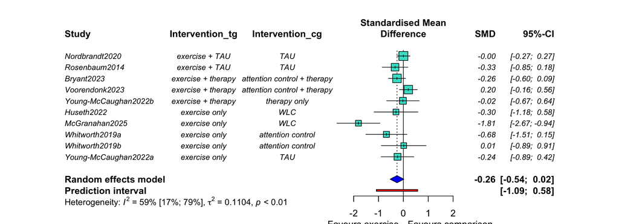

**Figure 3: Meta-analysis of the effects of exercise on PTSD symptom severity.**

#### Subgroup Analyses and Meta-regressions

##### Subgroup analysis by exercise intensity

The test for interaction found some evidence of a difference between studies with moderate intensity and those with high-intensity exercise (Figure 4). The effect of exercise appears to be larger in studies of high-intensity exercise compared to studies with moderate intensity

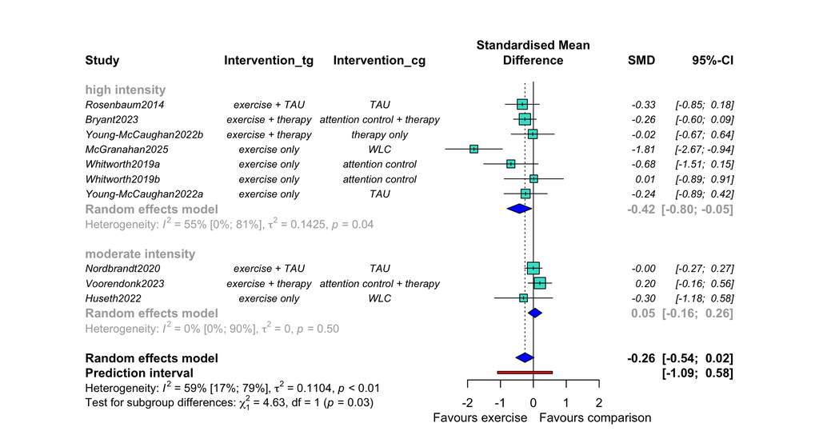

**Figure 4: Sub-group analysis of the effects of exercise on PTSD symptom severity by exercise intensity**

##### Subgroup analysis by specific exercise type

We did not find any important differences between the effects of aerobic, anaerobic, or mixed exercise groups (Figure 5).

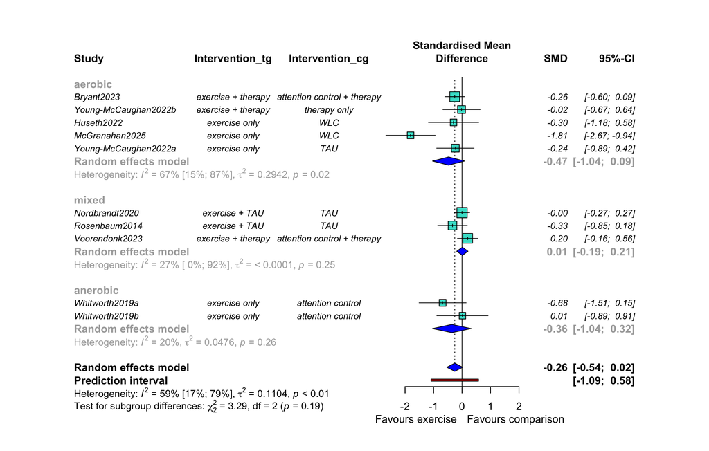

**Figure 5: Sub-group analysis of the effects of exercise on PTSD symptom severity by specific exercise type**

##### Subgroup analysis by exercise alone or tau/therapy augmented by exercise.

Studies with exercise alone as intervention seemed to show larger effects than those in studies where patients were additionally given treatment-as-usual or psychotherapy (Figure 6).

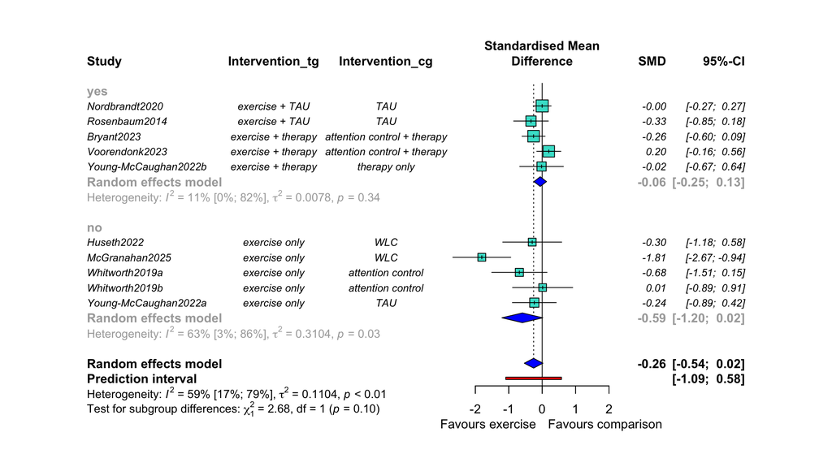

**Figure 6: Sub-group analysis of the effects of exercise on PTSD symptom severity by exercise alone or TAU/therapy augmented by exercise**

##### Meta-regression by intervention length

We performed a meta-regression for the intervention duration, despite the fact that we had only 9 studies (Figure 7). The meta-regression analysis yielded a coefficient of 0.03 (95% CI: -0.02, 0.09), indicating that for every additional week, the standardized mean difference (SMD) in PTSD symptoms increased by 0.03. This suggests there was no meaningful association between intervention duration and PTSD symptom severity.

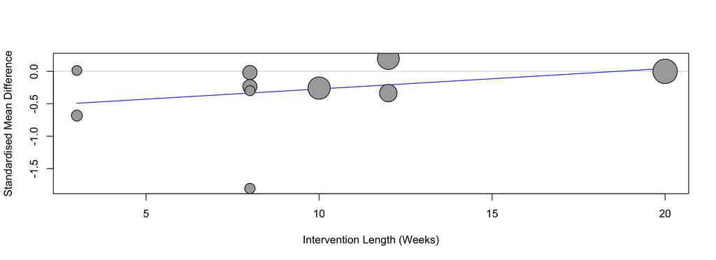

**Figure 7: Meta-regression of the effects of exercise on PTSD symptom severity by intervention length**

| Moderator | Category | $\beta$ | 95% CI | 𝞽<sup>2</sup> |
| --- | --- | --- | --- | --- |
| Overall effect | *-* | -0.26 | -0.54 to 0.02 | 0.11 |
| Exercise intensity | *-* | - | - | - |
|  | *Moderate* | 0.05 | -0.16 to 0.26 | 0 |
|  | *High* | -0.42 | -0.8 to -0.05 | 0.14 |
| Exercise type | *-* | - | - | - |
|  | *Aerobic* | -0.47 | -1.04 to 0.09 | 0.29 |
|  | *Anaerobic* | -0.36 | -1.04 to 0.32 | 0.05 |
|  | *Mixed* | 0.01 | -0.19 to 0.21 | 0 |
| Exercise augmentation | *-* | - | - | - |
|  | *Exercise alone* | -0.59 | -1.2 to 0.02 | 0.31 |
|  | *TAU/therapy + augmented* | -0.06 | -0.25 to 0.13 | 0.01 |
| Intervention length | *per unit (Week) increase* | 0.03 | -0.02 to 0.09 | 0.1 |

#### Sensitivity Analyses

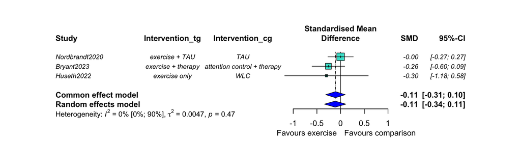

**Figure 8: Meta-analysis of the effects of exercise on PTSD symptom severity when excluding studies with high risk of bias**

#### Reporting bias

Visual inspection of the contour-enhanced funnel plot did not suggest possible publication bias in favour the of exercise group.

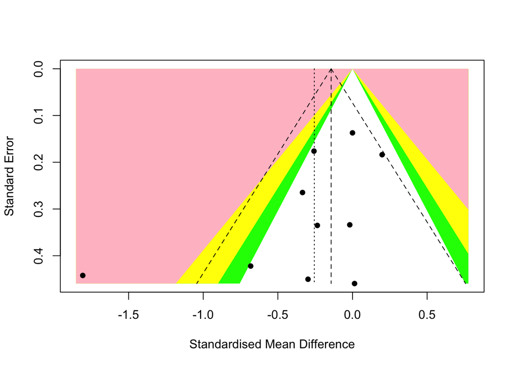

**Figure 9: Contour-enhanced funnel plot assessing publication bias**

Small-study effects were assessed using Egger’s regression test for funnel plot asymmetry. The test suggested potential asymmetry in the funnel plot (p-value = .095) although the contour-enhanced funnel plot does not indicate publication bias as a source for it. The estimated bias coefficient was -1.96, 1.04, indicating that smaller studies may be associated with larger effect sizes.

## Secondary outcomes

### Study dropout (weeks)

9 studies provided data for study dropout, and contributed 10 effect measures to the meta-analysis. The forest plot for the risk of dropout is presented in Figure 10.

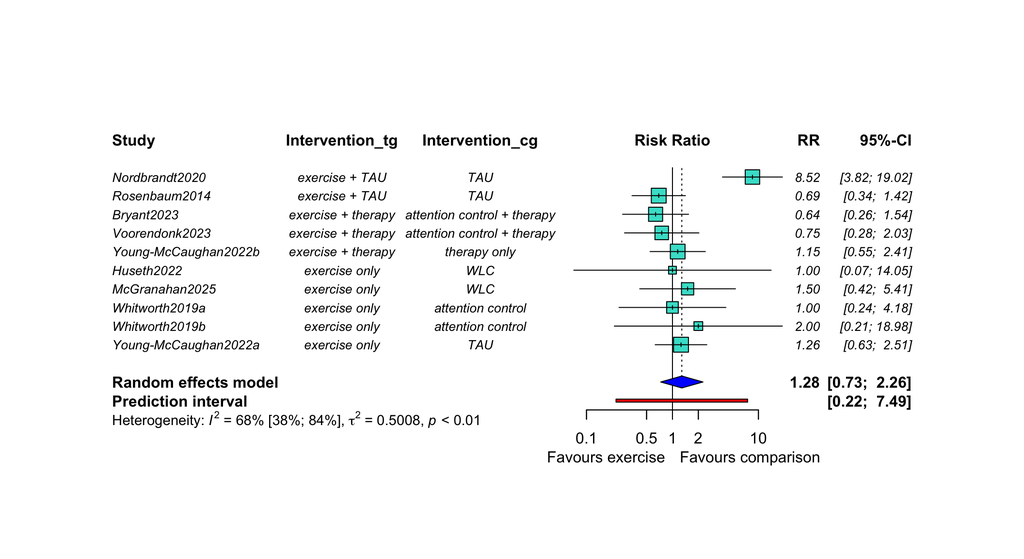

**Figure 10: Meta-analysis of the dropout rates between the intervention and control groups**

No evidence of a difference in dropout between exercise and comparison groups (RR = 1.28, 95% CI 0.73 to 2.26) was found and there was large heterogeneity, as shown by the prediction interval (0.22 to 7.49).